# STAT 4620 Final Project

Group 2: Brooke Bodine, Yoora Choi, Jake Denofsky, Cathy Wu

# Part I: Exploratory Data Analysis

## 1.1 Dataset Description

```r
# Read in merged training and testing datasets
merged_train <- read.csv("train.csv", stringsAsFactors = TRUE)
merged_test  <- read.csv("test.csv", stringsAsFactors = TRUE)
```

The Student Performance dataset originates from the UCI Machine Learning Repository and contains student records from two secondary school subjects: Mathematics and Portuguese. It captures a wide range of student characteristics, including demographic and family background, behavioral and lifestyle factors, school-related support information and academic history. For each student, academic performance is measured through three period grades (G1, G2, and G3), representing the first, second, and final course evaluations.

The dataset was originally released as two separate files, one for Math and one for Portuguese, sharing a common set of predictor variables but differing in subject-specific grade fields.

For this project, the instructor supplied merged training and testing datasets (`train.csv` and `test.csv`) in which shared predictors appear once, while subject-specific variables are labeled with the suffixes `.x` (Math) and `.y` (Portuguese).

## 1.2 Portuguese Subset Construction

```r
# Select variables shared between the math and Portuguese datasets
shared_vars <- c("school", "sex", "age", "address", "famsize", "Pstatus", "Medu",
                 "Fedu", "Mjob", "Fjob", "reason", "nursery", "internet")

# Build Portuguese subset for merged training data
por_train <- merged_train %>%
  select(all_of(shared_vars), ends_with(".y"), -G1.y, -G2.y) %>%
  rename_with(~ gsub("\\.y$", "", .x), ends_with(".y"))

# Build Portuguese subset for merged testing data
por_test <- merged_test %>%
  select(all_of(shared_vars), ends_with(".y"), -G1.y, -G2.y) %>%
  rename_with(~ gsub("\\.y$", "", .x), ends_with(".y"))
```

Because the dataset includes two subjects, Mathematics and Portuguese, their grade variables cannot be combined into a single response since they measure different outcomes. Therefore, we select only one subject to model. Since the Portuguese dataset contains substantially more observations than the Math dataset in the original UCI files (649 vs 395), it provides a more stable sample for model development, making Portuguese the natural choice for our analysis.

To remain consistent with this choice, we extract only the Portuguese portion of the merged training and testing datasets. In constructing this subset, we retain all shared predictors together with the Portuguese-specific grade variables and remove the `.y` suffix for clarity. We remove G1 and G2 as consideration from our predictors because G3 it is more useful to predict without using the first and second period grades.

## 1.3 Missing Values Checking

```r
# Check missing values
any(is.na(por_train))
```

```
## [1] FALSE
```

Since the function returns `FALSE`, we conclude that the Portuguese training dataset has no missing observations.

## 1.4 Variable Types Identifying

```r
# Identify variable types
numeric_vars <- names(por_train)[sapply(por_train, is.numeric)]
numeric_vars
```

```
##  [1] "age"        "Medu"       "Fedu"       "traveltime" "studytime"
##  [6] "failures"   "famrel"     "freetime"   "goout"      "Dalc"
## [11] "Walc"       "health"     "absences"   "G3"
```

```r
categorical_vars <- names(por_train)[sapply(por_train, is.factor)]
categorical_vars
```

```
##  [1] "school"     "sex"        "address"    "famsize"    "Pstatus"
##  [6] "Mjob"       "Fjob"       "reason"     "nursery"    "internet"
## [11] "guardian"   "schoolsup"  "famsup"     "paid"       "activities"
## [16] "higher"     "romantic"
```

The dataset includes 14 numeric variables and 17 categorical variables.

## 1.5 Response Variable Determining

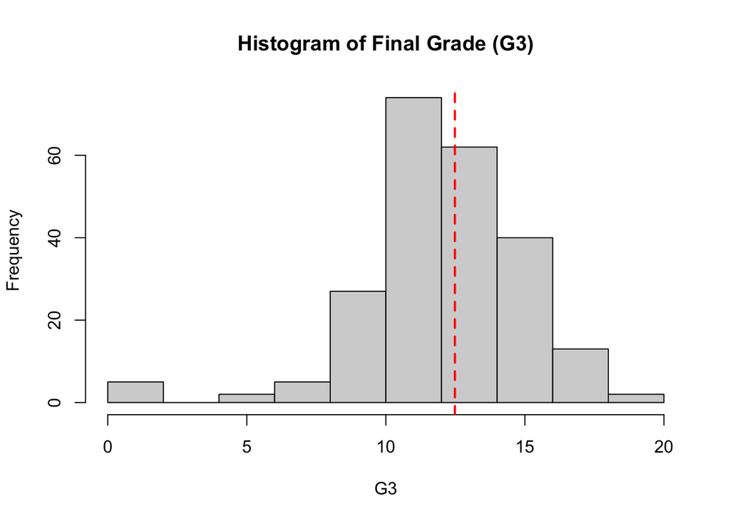

## 1.6 Predictor Variables Selection

Since the dataset contains both numeric and categorical predictors, we analyze these two types separately.

### 1.6.1 Numerical Predictors

#### 1.6.1.1 Correlation with Response Variable

```r
# Compute correlations between numeric predictors and G3
cor(por_train[, numeric_vars])[, "G3"]
```

```
##         age        Medu        Fedu  traveltime   studytime    failures
## -0.11404698  0.16426097  0.15450891 -0.15680110  0.21479813 -0.37919582
##      famrel    freetime       goout        Dalc        Walc      health
##  0.04572196 -0.06855391 -0.15515620 -0.35759097 -0.26831014 -0.17732065
##    absences          G3
## -0.14279598  1.00000000
```

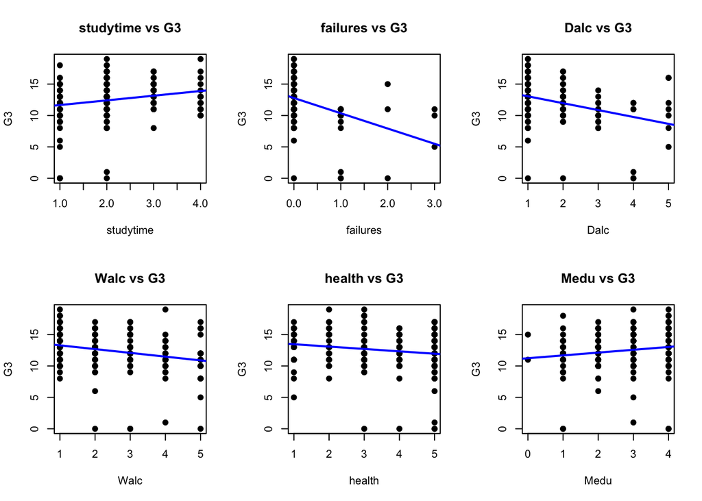

The correlation results show that the strongest numerical predictors of the final grade G3 are failures (the number of past class failures) and Dalc (workday alcohol consumption), with correlations of approximately -0.38 and -0.36, respectively. This moderate negative relationship is expected, as higher numbers of past class failures directly reflect a student’s academic record, and alcohol consumed during the workday might impair understanding and cognitive functions. Studytime exhibits a mild positive correlation with G3, while Walc (weekend alcohol consumption) exhibits a mild negative correlation. All remaining numerical variables display weak correlations with G3 and are therefore less likely to contribute substantially to prediction.

#### 1.6.1.2 Collinearity among Numerical Predictors

```r
# Compute correlation matrix for selected numerical predictors
selected_vars <- c("studytime", "failures", "Dalc", "Walc")
cor(por_train[, selected_vars])
```

```
##            studytime   failures       Dalc       Walc
## studytime  1.0000000 -0.1842892 -0.1607924 -0.2254378
## failures  -0.1842892  1.0000000  0.2400380  0.2320817
## Dalc      -0.1607924  0.2400380  1.0000000  0.6518753
## Walc      -0.2254378  0.2320817  0.6518753  1.0000000
```

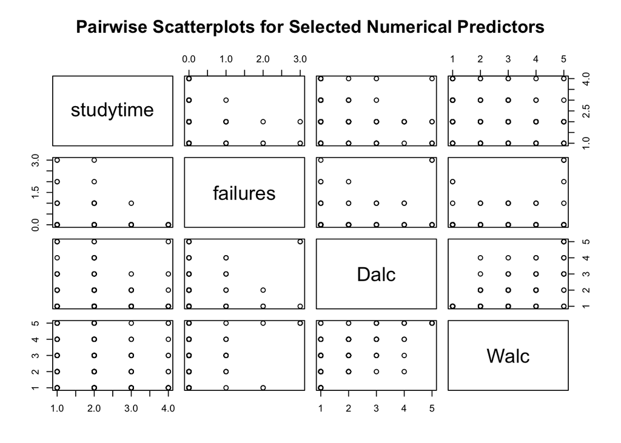

The collinearity analysis reveals moderately strong collinearity between Dalc and Walc, with a correlation of about 0.65, which is expected given they are both related to alcohol consumption. In contrast, the other numerical predictor combinations display only weak to moderate correlations with each other. Thus, collinearity is mainly concentrated in the alcohol consumption variables.

### 1.6.2 Categorical Predictors

```r
# Run ANOVA for each categorical variable and extract p-value
anova_results <- sapply(categorical_vars, function(var){
  model <- aov(por_train$G3 ~ por_train[[var]])
  summary(model)[[1]][["Pr(>F)"]][1]   # extract p-value
})

anova_results
```

```
##       school          sex      address      famsize      Pstatus         Mjob
## 8.975233e-03 2.751371e-03 4.243570e-03 5.599660e-01 2.128401e-01 1.356414e-02
##         Fjob       reason      nursery     internet     guardian    schoolsup
## 8.978637e-01 5.735972e-03 5.084768e-01 2.989810e-02 3.361413e-01 3.851009e-02
##       famsup         paid   activities       higher     romantic
## 4.977146e-01 2.208247e-02 3.762429e-03 4.577715e-06 4.411111e-01
```

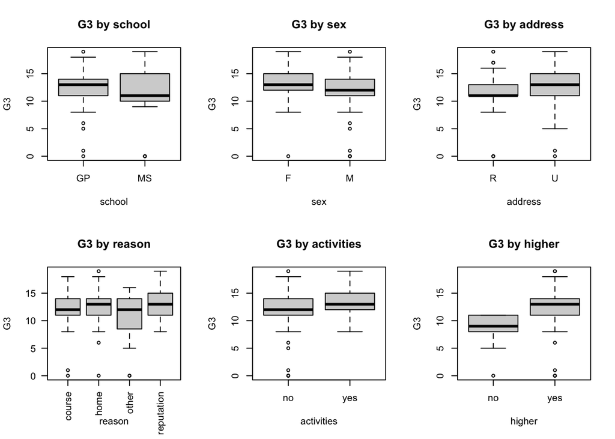

ANOVA results indicate that six categorical variables have strong associations with G3 (p < 0.01): school, sex, address, reason, activities, and higher. The corresponding boxplots illustrate the grade differences across their groups, confirming their relevance as key categorical predictors.

Therefore, these numerical (studytime, failures, Dalc, Walc) and categorical (school, sex, address, reason, activities, higher) predictors will be the primary variables considered in the subsequent modeling stage.

## 1.7 Models Consideration

The exploratory analysis provides clear guidance on which modeling approaches are appropriate for predicting the final grade G3. The strongest numerical predictors are failures and Dalc, which show negative correlations with G3. Their moderate linear relationships suggest that a linear modeling framework is a natural starting point. However, because Dalc and Walc are also highly collinear with each other, regularization methods are needed to stabilize coefficient estimates when both variables are included. In addition to numerical predictors, several categorical variables show statistically significant group differences in G3, indicating that models must be capable of incorporating factor variables. Based on these insights, three modeling approaches are selected for further investigation: linear regression, ridge regression, and random forest.

# Part II: Model Analysis

## 2.1 Data Preparation

```r
# Select variables from EDA
final_vars <- c("G3",
                "studytime", "failures", "Dalc", "Walc",
                "school", "sex", "address", "reason", "activities", "higher")

# Subset the Portuguese training and testing data for modeling
model_train <- por_train[, final_vars]
model_test  <- por_test[, final_vars]
```

Before fitting predictive models, we construct the modeling dataset using the variables identified during the exploratory analysis. The final modeling dataset consists of the response variable G3 and these selected predictors.

## 2.2 Models Building

### 2.2.1 Linear Regression

#### 2.2.1.1 Motivation

A linear model provides a simple and interpretable baseline for prediction. Because several predictors, such as studytime and failures, show clear linear relationships with G3, an additive linear structure is well suited for modeling overall performance and evaluating the roles of both numerical and categorical predictors.

Although Dalc and Walc exhibit moderate collinearity, linear regression remains appropriate as a baseline model, since multicollinearity affects the stability of individual coefficients but does not compromise the model’s overall predictive accuracy.

#### 2.2.1.2 Specification

The linear regression model assumes a linear relationship between the response and predictors

$$G_{3i} = \beta_0
+ \beta_1 \, studytime_i
+ \beta_2 \, failures_i
+ \beta_3 \, Dalc_i
+ \beta_4 \, Walc_i
+ \sum_{j=5}^{10} \beta_j X_{ij}
+ \varepsilon_i,$$

The error term $\varepsilon$ is assumed to have mean zero and constant variance.

#### 2.2.1.3 Assumption

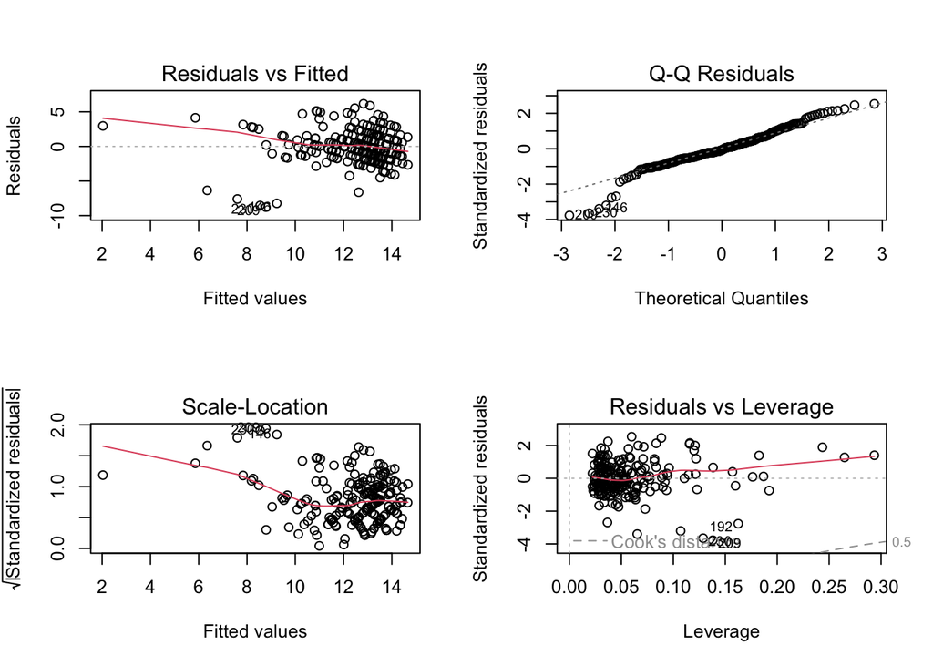

```r
# Fit Linear Regression Model
lm_fit <- lm(G3 ~ ., data = model_train)

# Produce diagnostic plots for the linear model
par(mfrow = c(2, 2)) # 2 rows, 2 columns layout
plot(lm_fit)
```

Linear regression relies on four key assumptions: linearity, normality, equal error variance and independence. The diagnostic plots provide the following evidence for each:

##### Linearity

The Residuals vs Fitted plot shows a slight downward trend rather than a perfectly flat horizontal band, indicating that the relationship between the predictors and the response is not perfectly linear. This suggests only a mild deviation from the linearity assumption.

##### Normality

The Q–Q plot is mostly aligned with the theoretical line, especially in the center. However, some deviations appear in the lower tail, indicating that the residuals are not perfectly normally distributed. Overall, normality is reasonably acceptable, though the tail departure suggests minor non-normality.

##### Equal Error Variance (Homoscedasticity)

The Scale–Location plot shows a clear downward trend in the spread of the standardized residuals, indicating that the variability of the residuals decreases as the fitted values increase. This pattern suggests a violation of the constant variance assumption, meaning the model exhibits heteroscedasticity.

##### Independence

The Residuals vs Leverage plot does not reveal any strong clustering patterns or unusually influential points. Although a few observations show moderately high leverage, none of them exceed Cook’s distance thresholds. Since there is no clear evidence of dependence among the errors, the independence assumption appears reasonably satisfied.

#### 2.2.1.4 Validation

```r
# Predict on the test set
lm_pred <- predict(lm_fit, newdata = model_test)

# Compute Test MSE
lm_mse <- mean((model_test$G3 - lm_pred)^2)
lm_mse
```

```
## [1] 7.022477
```

The linear Regression model achieves a test MSE of 7.022477.

### 2.2.2 Ridge Regression

#### 2.2.2.1 Motivation

Ridge regression is used to address the collinearity between predictors. By shrinking coefficients, it produces more stable estimates and can improve predictive performance compared to ordinary least squares.

#### 2.2.2.2 Specification

Ridge regression estimates the coefficients by solving the penalized optimization problem

$$\widehat{\beta}_{ridge}
= \arg\min_{\beta}
\Bigl\{
\sum_{i=1}^{n}
\bigl(
G_{3i}
- \beta_0
- \beta_1 studytime_i
- \beta_2 failures_i
- \beta_3 Dalc_i
- \beta_4 Walc_i
- \sum_{j=5}^{10} \beta_j X_{ij}
\bigr)^{2}
\;+\;
\lambda \sum_{j=1}^{p} \beta_j^{2}
\Bigl\},$$

The tuning parameter $\lambda\ge 0$ controls the amount of shrinkage applied to the coefficients, with larger values producing greater regularization.

The intercept $\beta_0$ is not penalized.

#### 2.2.2.3 Assumption

Ridge regression relies on the usual linear regression assumptions of linearity, normality, equal error variance or independence, and our earlier diagnostic checks for the linear model provide the relevant evidence. Unlike OLS, however, ridge does not require predictors to be uncorrelated and is specifically designed to handle multicollinearity by shrinking coefficients toward zero.

#### 2.2.2.4 Validation

```r
# Prepare model matrices
x_train <- model.matrix(G3 ~ ., data = model_train)[, -1]  # drop intercept column
y_train <- model_train$G3

x_test <- model.matrix(G3 ~ ., data = model_test)[, -1]
y_test <- model_test$G3

# Perform cross-validation to select optimal lambda
ridge_cv <- cv.glmnet(x_train, y_train, alpha = 0)

# Extract best lambda
best_lambda <- ridge_cv$lambda.min
best_lambda
```

```
## [1] 1.835726
```

```r
# Fit ridge model
ridge_fit <- glmnet(x_train, y_train, alpha = 0, lambda = best_lambda)

# Predict on the test set
ridge_pred <- predict(ridge_fit, s = best_lambda, newx = x_test)

# Compute Test MSE
ridge_mse <- mean((y_test - ridge_pred)^2)
ridge_mse
```

```
## [1] 6.724149
```

### 2.2.3 Random Forest

#### 2.2.3.1 Motivation

Random Forest provides a flexible, high-performance modeling approach that captures nonlinear relationships and interactions. Its use of bootstrap aggregation and random feature selection reduces variance and improves predictive accuracy compared with linear models.

#### 2.2.3.2 Specification

In this project, the random forest model is trained using numerical predictors together with the dummy variables created from the categorical predictors. The model consists of an ensemble of regression trees, each grown on a bootstrap sample of the training data. At every split within a tree, only a randomly selected subset of these predictors is considered when determining the best splitting rule.

The prediction produced by the random forest for a new observation $x$ is defined as

$$\widehat{f}_{RF}(x)
=
\frac{1}{B}
\sum_{b=1}^{B}
T_b(x),$$

where $B$ is the total number of trees in the ensemble and $T_b(x)$ denotes the predicted value of G3 from the $b$-th bootstrap tree constructed using a bootstrap sample and random subsets of predictors.

The use of bootstrap samples introduces variation among the individual trees, and random predictor selection at each split reduces the correlation between trees. Averaging across the resulting collection of decorrelated trees reduces prediction variance. Variable importance is evaluated using the percent increase in out-of-bag mean squared error and the total reduction in node impurity across all trees.

#### 2.2.3.3 Assumption

Random Forest is a non-parametric ensemble method and does not rely on linear regression assumptions such as linearity, normality, equal error variance or independence. Its validity comes from bootstrap aggregation and variance reduction rather than assumptions about the data-generating process. The main requirement is simply that the training data contain enough signal for splits to be meaningful.

#### 2.2.3.4 Validation

```r
# Set seed for reproducibility
set.seed(2)

# Fit Random Forest model
rf_fit <- randomForest(G3 ~ ., data = model_train, importance = TRUE)

# Predict on test set
rf_pred <- predict(rf_fit, newdata = model_test)

# Compute Test MSE
rf_mse <- mean((model_test$G3 - rf_pred)^2)
rf_mse
```

```
## [1] 6.778529
```

The random forest model achieves a test MSE of 6.778529.

## 2.3 Results

### 2.3.1 Predictive Performance

We compare the predictive accuracy of the three candidate models using the test dataset.

```r
# Create a comparison table
mse_table <- data.frame(
  Model = c("Linear Regression", "Ridge Regression", "Random Forest"),
  Test_MSE = c(lm_mse, ridge_mse, rf_mse)
)

mse_table
```

```
##               Model Test_MSE
## 1 Linear Regression 7.022477
## 2  Ridge Regression 6.724149
## 3     Random Forest 6.778529
```

From the results, random forest performs better than ordinary least squares regression. This suggests that some nonlinear patterns and interactions in the data can be captured by tree-based methods. Ridge regression performs the best with the lowest test MSE among all models, suggesting that the multicollinearity between predictors hurts OLS but is handled well by ridge. Because ridge regression balances bias and variance effectively and provides the best performance on the test data, we select ridge regression as our final model.

### 2.3.2 Model Interpretation

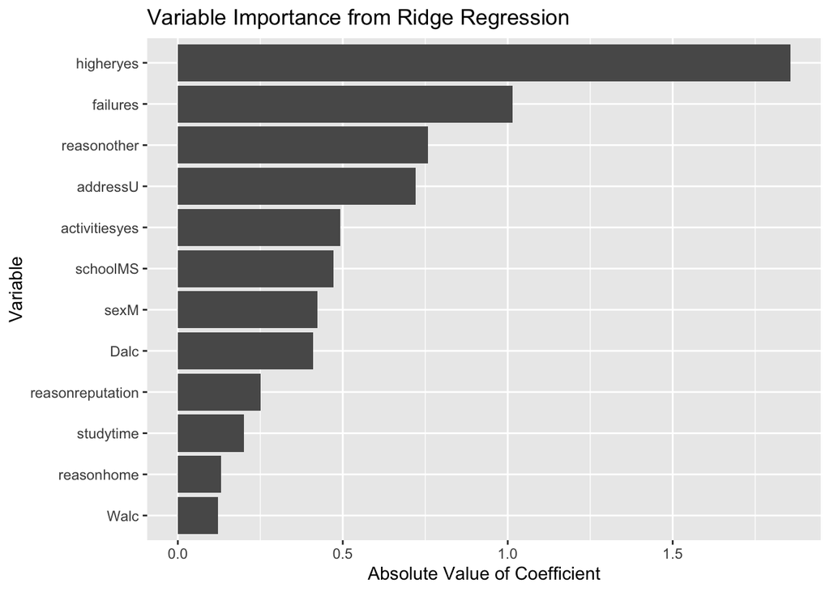

```r
# Extract coefficients at our optimal lambda
ridge_coefs <- coef(ridge_fit, s = best_lambda)

# Convert to data frame, exclude intercept
coef_df <- data.frame(
  Variable = rownames(ridge_coefs)[-1],
  Coefficient = as.numeric(ridge_coefs[-1])
)

# Plot coefficient values from ridge regression
ggplot(coef_df, aes(x = reorder(Variable, abs(Coefficient)), y = abs(Coefficient))) +
  geom_bar(stat = "identity") +
  coord_flip() +
  labs(
    title = "Variable Importance from Ridge Regression",
    y = "Absolute Value of Coefficient",
    x = "Variable"
  )
```